# task13

Paulius Kostickis

Monday, April 25, 2016

1. For the following series, find an appropriate Box-Cox transformation and order of differencing in order to obtain stationary data.
1. usnetelec
2. usgdp
3. mcopper
4. enplanements
5. visitors

#### Funkcija skirta transformuoti duomenis ir išbrėžti transformuotus stacionarius ir pradinius duomenis

(Funkciją “grafikas” sukūriau pats, dvi eilutės automatinio diferencijavimo buvo rastos “fpp” knygoje)

```r
grafikas <-function(data, sez){
  par(mfrow=c(1,3))
  ns=0                                                #kad nebūtų klaidinama kiek kartų differencijuota
  lambda = BoxCox.lambda(data)                        #randamas lambda
  trdiff = BoxCox(data,lambda = lambda)               #transformuojami duomenys

  if(sez==T){                                         #naikinamas sezoniškumo įtaka, jei yra sezoniškumas
    ns <- nsdiffs(trdiff)
    if(ns>0)
      trdiff <- diff(trdiff,lag=frequency(trdiff), differences=ns)
  }

  nd <- ndiffs(trdiff)                                #diferencijuojama, jei trendas yra
  if(nd > 0)
    trdiff <- diff(trdiff,differences=nd)

  plot(data, main="pradinis")                            #pradinių duomenų grafikas
  plot(trdiff, ylab="pokytis", main= "stacionarus")
  acf(trdiff, main = "nera nei sezoniskmo nei trendo")   #stacionarių duomenų grafikas
  p=kpss.test(trdiff)$p.value

    return(kable(data.frame(trendo_diferencijavimas = nd , sezono_diferencijavimas = ns, iš_viso_diferencijuota = nd + ns,Lambda = lambda, p_reiksme=p)))            #atspausdinama statistinė lentelė
}
```

#### (a) usnetelec

Matome, kad tik trendas yra. Galutinė laiko eilutė stacionari, teste neatmetame H0, kad laiko eilutė stacionari.

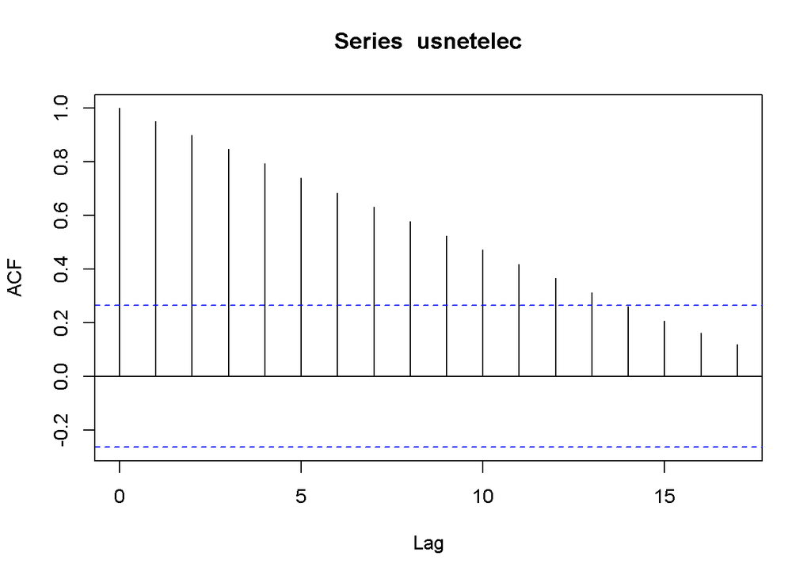

```r
acf(usnetelec)
```

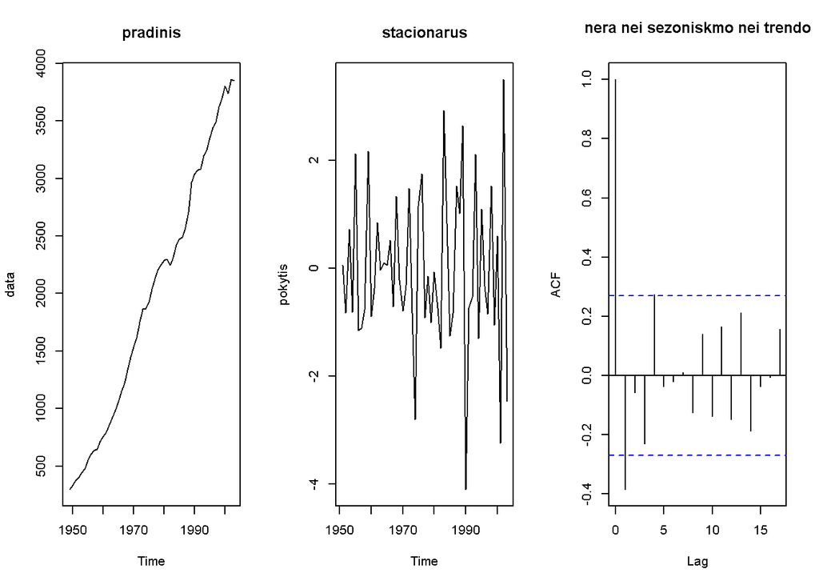

| trendo_diferencijavimas | sezono_diferencijavimas | iš_viso_diferencijuota | Lambda | p_reiksme |
| --- | --- | --- | --- | --- |
| 2 | 0 | 2 | 0.5167714 | 0.1 |

```r
grafikas(usnetelec,F) #tik su trendu
```

Kadangi p value > 0.05, neatmetame H0 - laiko eilutė stcionari.

#### (b) usgdp

Matome, kad tik trendas yra. Galutinė laiko eilutė stacionari, teste neatmetame H0, kad laiko eilutė stacionari.

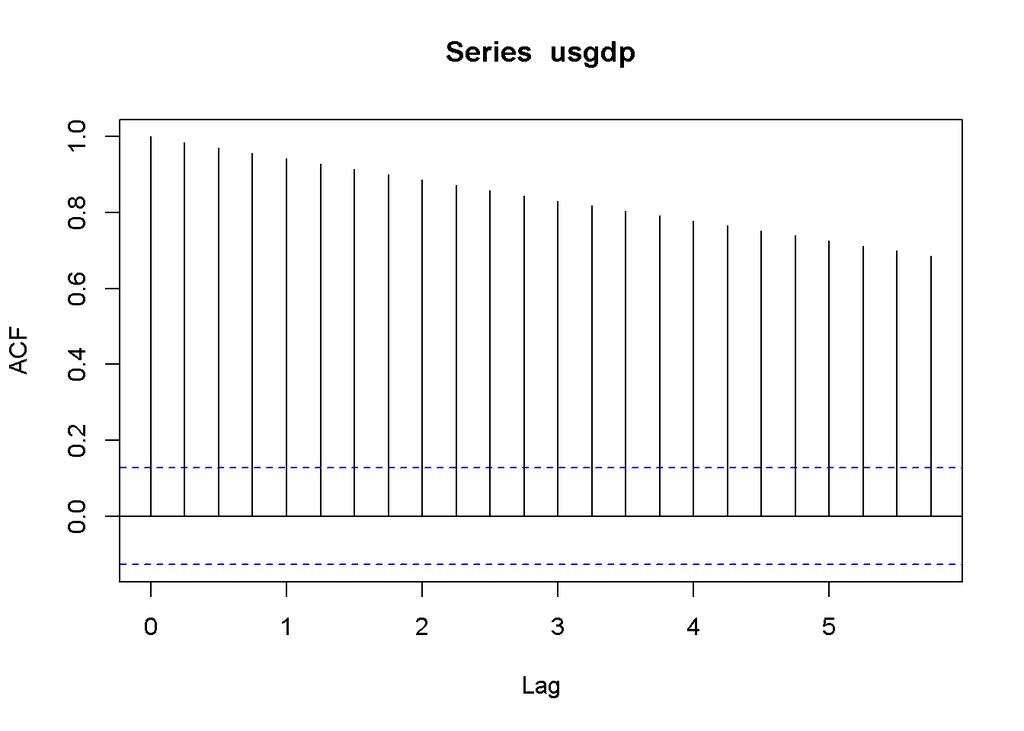

```r
acf(usgdp)           #tik su trendu, taigi funkcijoje tai pažymėsime
```

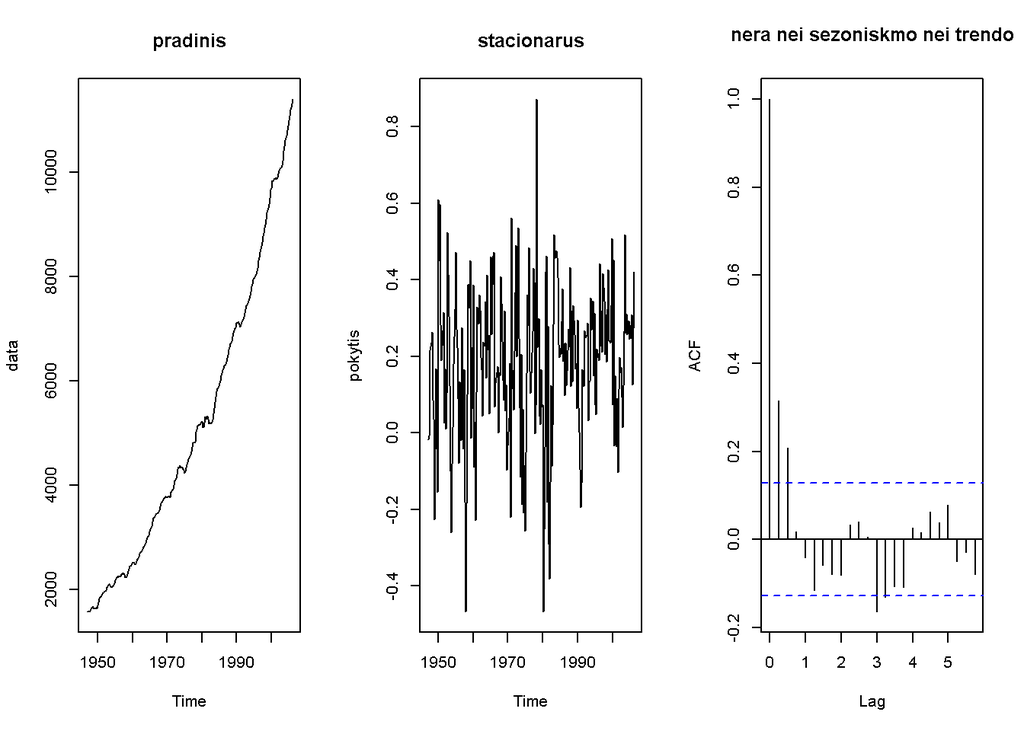

| trendo_diferencijavimas | sezono_diferencijavimas | iš_viso_diferencijuota | Lambda | p_reiksme |
| --- | --- | --- | --- | --- |
| 1 | 0 | 1 | 0.366352 | 0.1 |

```r
grafikas(usgdp,F)
```

Kadangi p value > 0.05, neatmetame H0 - laiko eilutė stcionari.

#### (c) mcopper

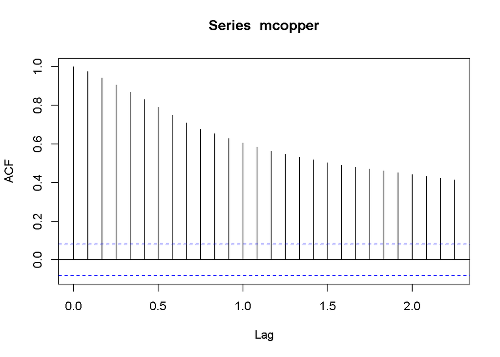

```r
acf(mcopper)         #tik su trendu, taigi funkcijoje tai pažymėsime
```

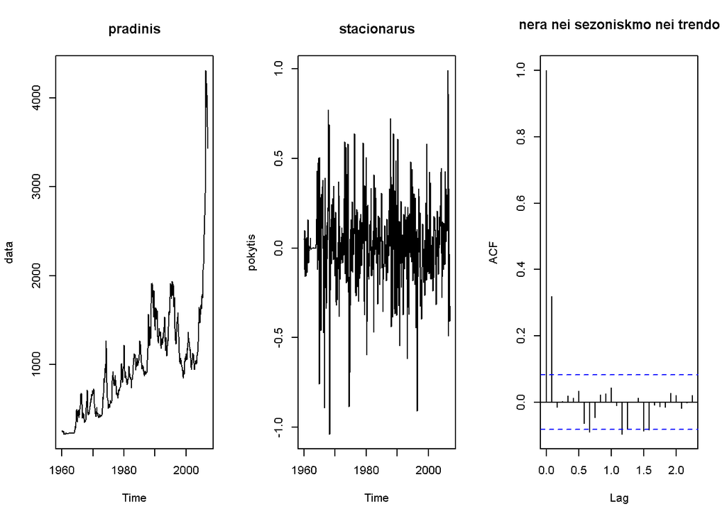

| trendo_diferencijavimas | sezono_diferencijavimas | iš_viso_diferencijuota | Lambda | p_reiksme |
| --- | --- | --- | --- | --- |
| 1 | 0 | 1 | 0.1919047 | 0.1 |

```r
grafikas(mcopper,F)
```

Kadangi p value > 0.05, neatmetame H0 - laiko eilutė stcionari.

#### (d) enplanements

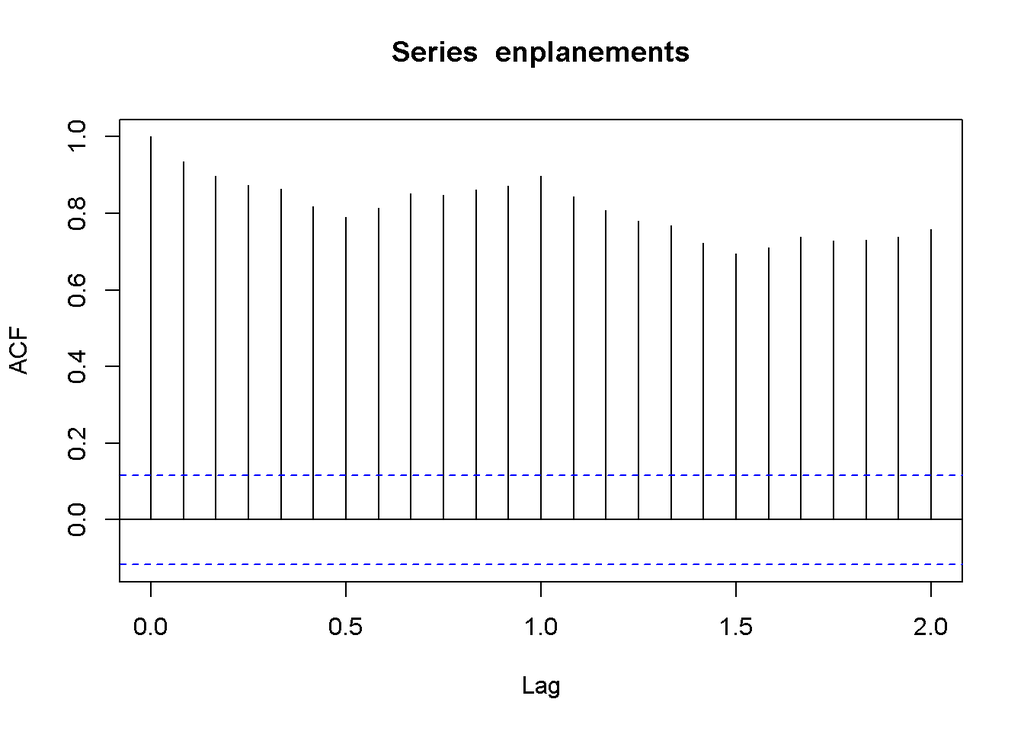

```r
acf(enplanements)    #matosi sezoniškumas, taigi funkcijoje tai pažymėsime
```

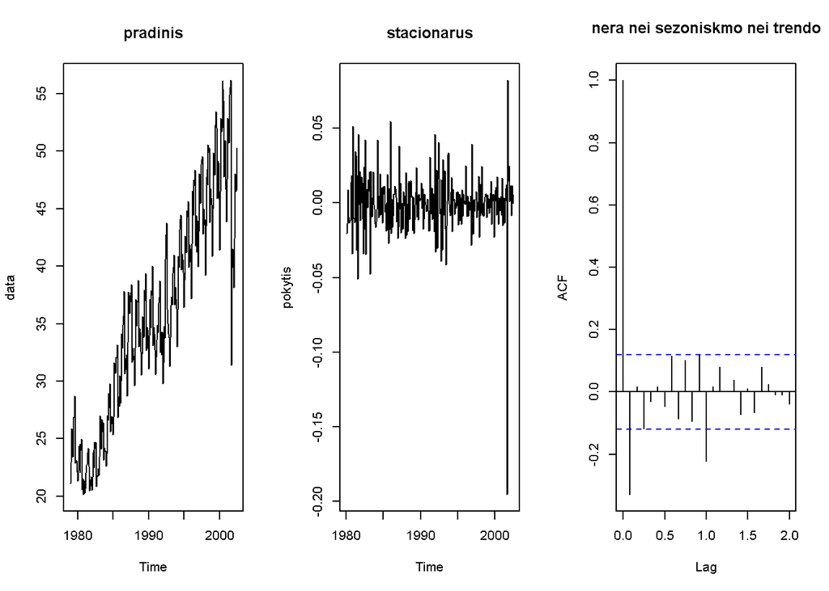

| trendo_diferencijavimas | sezono_diferencijavimas | iš_viso_diferencijuota | Lambda | p_reiksme |
| --- | --- | --- | --- | --- |
| 1 | 1 | 2 | -0.2269461 | 0.1 |

```r
grafikas(enplanements,T)
```

Kadangi p value > 0.05, neatmetame H0 - laiko eilutė stcionari.

#### (e) visitors

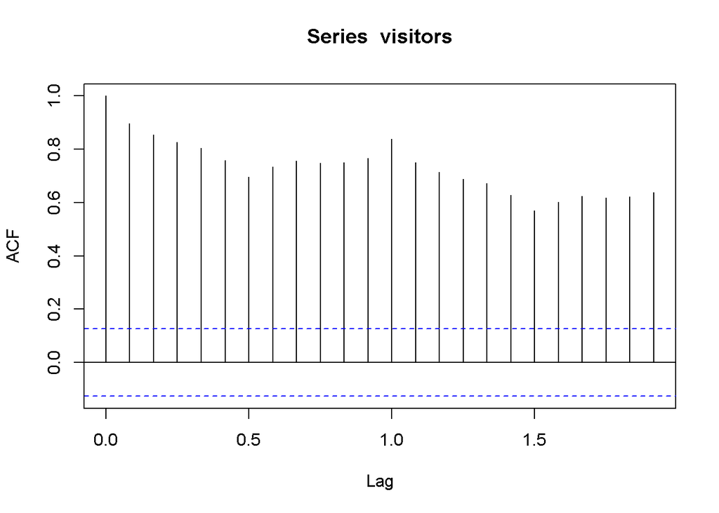

```r
acf(visitors)   #matosi sezoniškumas, taigi funkcijoje tai pažymėsime
```

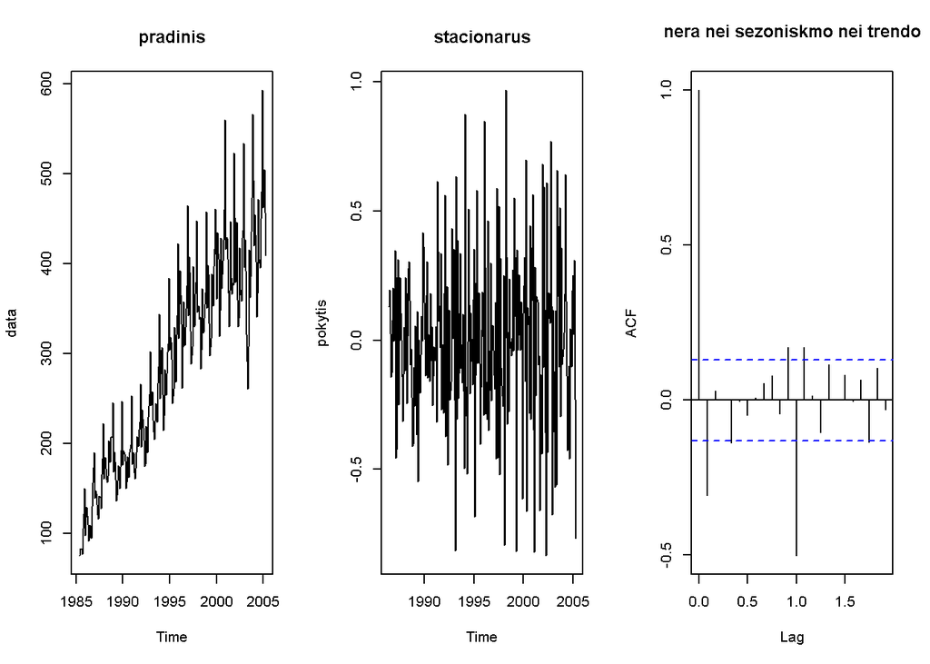

| trendo_diferencijavimas | sezono_diferencijavimas | iš_viso_diferencijuota | Lambda | p_reiksme |
| --- | --- | --- | --- | --- |
| 1 | 1 | 2 | 0.2775249 | 0.1 |

```r
grafikas(visitors,T)
```

Kadangi p value > 0.05, neatmetame H0 - laiko eilutė stcionari.

2. Why is a Box-Cox transformation unhelpful for the cangas data?

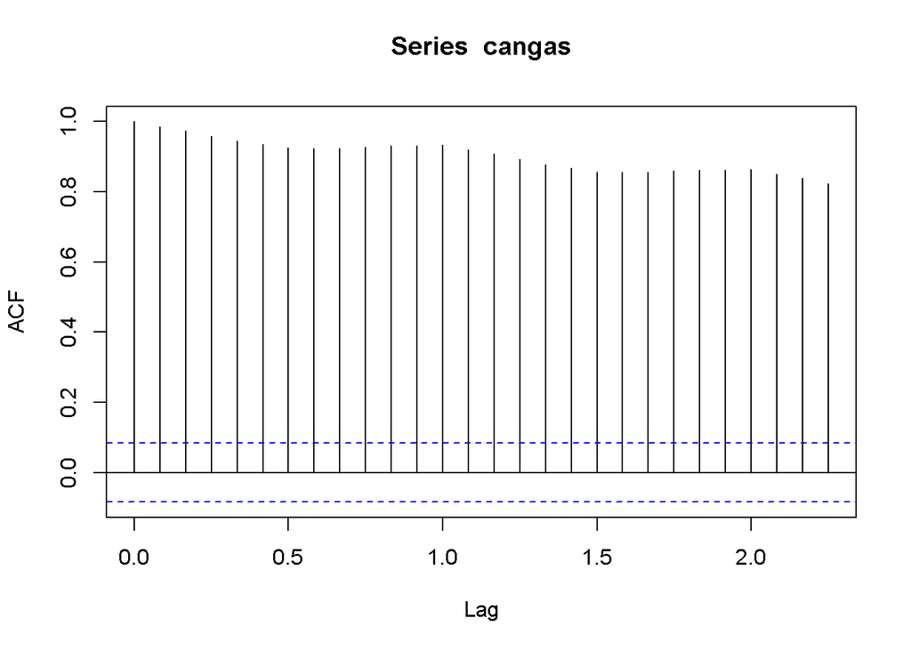

```r
acf(cangas)     #matosi sezoniškumas, taigi funkcijoje tai pažymėsime
```

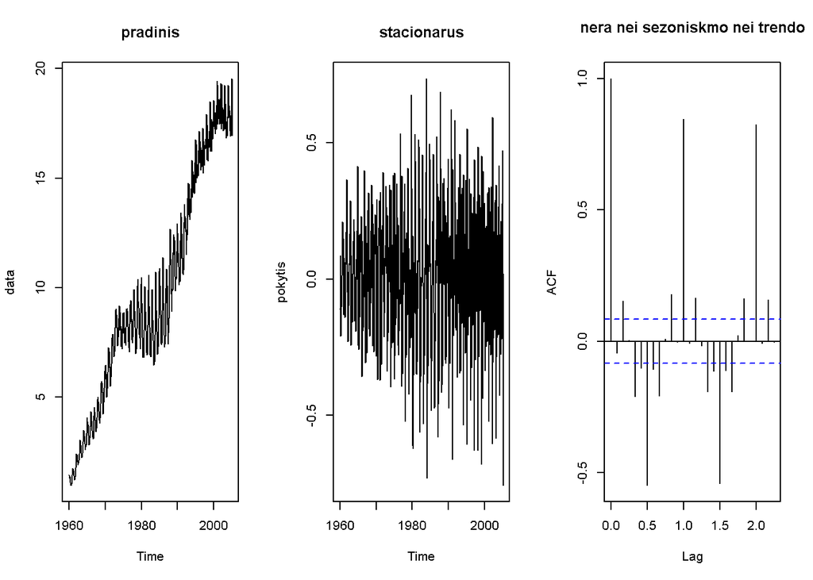

| trendo_diferencijavimas | sezono_diferencijavimas | iš_viso_diferencijuota | Lambda | p_reiksme |
| --- | --- | --- | --- | --- |
| 1 | 0 | 1 | 0.5767759 | 0.1 |

```r
grafikas(cangas,T)
```

Matosi, kad transformuotų duomenų sklaida vistiek didelė, taigi Box-Cox transformacija nepadėjo.

3. Download the data at http://robjhyndman.com/data/retail.xls. Choose one of the series and find an appropriate Box-Cox transformation and order of differencing in order to obtain stationary data.

```r
data=read.csv("retail.csv")
```

Renkuosi 6-tą duomenų stulpelį

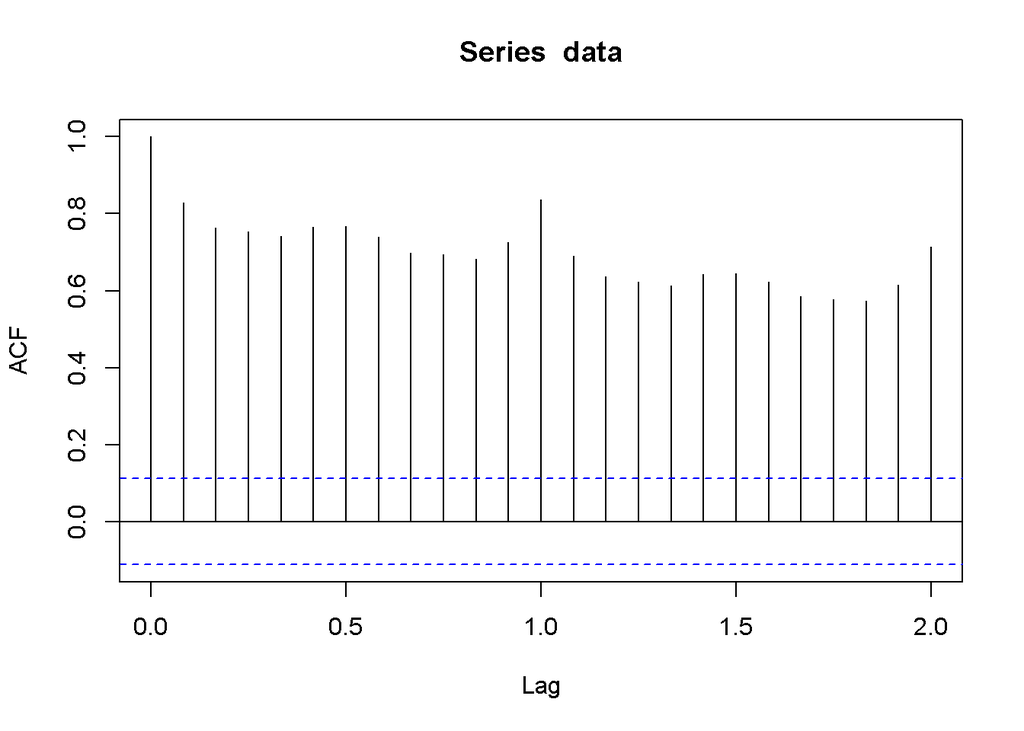

```r
data=ts(data[,7],start=c(1982,5), frequency=12)
acf(data)
```

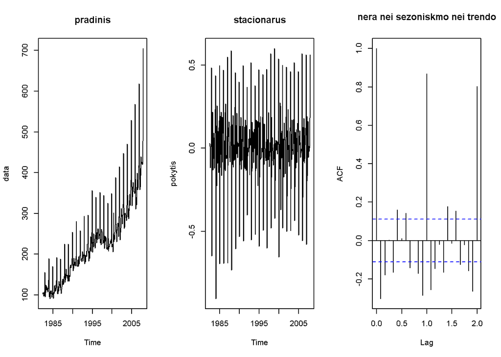

| trendo_diferencijavimas | sezono_diferencijavimas | iš_viso_diferencijuota | Lambda | p_reiksme |
| --- | --- | --- | --- | --- |
| 1 | 0 | 1 | 0.0574908 | 0.1 |

```r
grafikas(data,F)                               #tik su trendu, taigi funkcijoje tai pažymėsime
```